# Create a 3D model of a Permo-Carboniferous Trough (PCT)

The lithological units comprise the permo-carboniferous filling (paleozoic), Mesozoic, Tertiary strata, as well as the Palaeozoic crystalline basement rocks.

```python
from platform import python_version

print(python_version())
```

```
3.7.6
```

```python
# These two lines are necessary only if GemPy is not installed via pip
import sys, os
sys.path.append(r'../../../gempy/')
#sys.path.append(r'/Users/nijan/Documents/git/gempy/')

# Importing GemPy
import gempy as gp

# Importing auxilary libraries
import numpy as np
import matplotlib.pyplot as plt
import matplotlib.image as mpimg

# For embedding matplotlib figures
%matplotlib inline
import pyvista as pv
pv.set_plot_theme("document")
```

```python
import gempy.plot.vista
```

```python
# Import improved plotting features
from gempy.plot import visualization_2d as vv
from gempy.plot import vista
```

# Initialize the model

We start with modelling the trough by generating a gempy model object. This will use interface points and orientations, which we previously stored in a `.csv` file.

```python
# Import data
# Create a model instance
geo_model = gp.create_model('PCT_model')

# Initialize the model, set dimension and load interface and orientation data
gp.init_data(geo_model, [2635000, 2680000., 1240000., 1272000., -6000, 1000.], [80, 70, 70],
            path_i = '../../data/processed/GemPy/jordan_profile/New_profile_clicks/all_interfaces_concat_WITH_thrust_meso_reduced_pct_adjusted.csv',
            path_o = '../../data/processed/GemPy/jordan_profile/New_profile_clicks/20200706_orientations_with_thrusts_mesozoic_adjusted.csv');
#topo = geo_model.set_topography(source='gdal', filepath='../../data/processed/GemPy/Model_DTM_EPSG2056.tif');
geo_model.set_topography(source='gdal', filepath='../../data/processed/GemPy/Model_DTM_EPSG2056.tif');
```

```
Active grids: ['regular']
Cropped raster to geo_model.grid.extent.
depending on the size of the raster, this can take a while...
storing converted file...
Active grids: ['regular' 'topography']
```

```python
# Set the interpolator function
# Create the theano model
gp.set_interpolator(geo_model,
                         compile_theano=True,
                         theano_optimizer='fast_compile',
                         verbose=[]);
```

```
Setting kriging parameters to their default values.
Compiling theano function...
Level of Optimization:  fast_compile
Device:  cpu
Precision:  float64
Number of faults:  0
Compilation Done!
Kriging values:
                       values
range                55659.7
$C_o$            7.37619e+07
drift equations       [3, 3]
```

## Setting up Cross sections from the Nagra Report

```python
# set 3 sections which go North South
section_dict = {'section4_3':([2670826,1268793],[2676862,1255579],[100,100]),
                 'section4_4':([2649021,1267107],[2659842,1246715],[100,100]),
                 'section4_8':([2643284,1259358],[2680261,1268521],[100,100])}
```

```python
geo_model.set_section_grid(section_dict)
```

```
Active grids: ['regular' 'topography' 'sections']
```

|  | start | stop | resolution | dist |
| --- | --- | --- | --- | --- |
| section4_3 | [2670826, 1268793] | [2676862, 1255579] | [100, 100] | 14527.322258 |
| section4_4 | [2649021, 1267107] | [2659842, 1246715] | [100, 100] | 23085.226986 |
| section4_8 | [2643284, 1259358] | [2680261, 1268521] | [100, 100] | 38095.394709 |

## Plot Data in 3D

```python
gp.plot_3d(geo_model, show_surfaces=False, show_data=True, show_lith=False,
           image=False, plotter_type='background')
```

```
<gempy.plot.vista.GemPyToVista at 0x1f78312bc48>
```

# Display Model Information

## Surfaces

```python
geo_model.surfaces
```

|  | surface | series | order_surfaces | color | id |
| --- | --- | --- | --- | --- | --- |
| 0 | BIH-Basement-N | Default series | 1 | #015482 | 1 |
| 1 | Fault_Basement_A | Default series | 2 | #9f0052 | 2 |
| 2 | Fault-south | Default series | 3 | #ffbe00 | 3 |
| 3 | graben-fill | Default series | 4 | #728f02 | 4 |
| 4 | Mittlerer-Muschelkalk | Default series | 5 | #443988 | 5 |
| 5 | Vorwald_Basement | Default series | 6 | #ff3f20 | 6 |
| 6 | Jurathrust4 | Default series | 7 | #5DA629 | 7 |
| 7 | Mandach | Default series | 8 | #4878d0 | 8 |
| 8 | Jurathrust6 | Default series | 9 | #ee854a | 9 |
| 9 | Dogger | Default series | 10 | #6acc64 | 10 |
| 10 | Effinger-Schichten | Default series | 11 | #d65f5f | 11 |
| 11 | Keuper | Default series | 12 | #956cb4 | 12 |
| 12 | Malm | Default series | 13 | #8c613c | 13 |
| 13 | Oberer-Muschelkalk | Default series | 14 | #dc7ec0 | 14 |
| 14 | Opalinuston | Default series | 15 | #797979 | 15 |
| 15 | basement | Basement | 1 | #d5bb67 | 16 |

## Characteristics

Main features of the model is the asymetric graben system, with the major fault (denoted with **A**), and the graben fill, which is not present beyond the graben shoulders. This, as well as the stop of major faults beneath the mesozoic units (blue units) are important considerations for the modelling process.  
These could be caught, for instance, in likelihood functions if we model the PCT as a Bayesian inference problem.

```python
# Assign formations to series
gp.map_series_to_surfaces(geo_model,
                         {"Thrust_Mandach": 'Mandach',
                          "Thrust_Jura": 'Jurathrust4',
                          "Thrust_Jura6": 'Jurathrust6', #('Jurathrust4', 'Jurathrust5', 'Jurathrust6'),
                          "Fault_north_series": 'Fault_Basement_A',
                          "Fault_south_series": 'Fault-south',
                          "Vorwald_series": 'Vorwald_Basement',
                          "BIH_series": 'BIH-Basement-N',
                          "Fault_north_series": 'Fault_Basement_A',
                          "Fault_south_series": 'Fault-south',
                         "Post_graben_series": ('Malm', 'Effinger-Schichten',
                                               'Dogger', 'Opalinuston', 'Keuper',
                                               'Oberer-Muschelkalk'),
                          "Detachement": 'Mittlerer-Muschelkalk',
                         "Graben_series": 'graben-fill'},
                         remove_unused_series=True)
geo_model.surfaces
```

|  | surface | series | order_surfaces | color | id |
| --- | --- | --- | --- | --- | --- |
| 7 | Mandach | Thrust_Mandach | 1 | #4878d0 | 1 |
| 6 | Jurathrust4 | Thrust_Jura | 1 | #5DA629 | 2 |
| 8 | Jurathrust6 | Thrust_Jura6 | 1 | #ee854a | 3 |
| 1 | Fault_Basement_A | Fault_north_series | 1 | #9f0052 | 4 |
| 2 | Fault-south | Fault_south_series | 1 | #ffbe00 | 5 |
| 5 | Vorwald_Basement | Vorwald_series | 1 | #ff3f20 | 6 |
| 0 | BIH-Basement-N | BIH_series | 1 | #015482 | 7 |
| 9 | Dogger | Post_graben_series | 1 | #6acc64 | 8 |
| 10 | Effinger-Schichten | Post_graben_series | 2 | #d65f5f | 9 |
| 11 | Keuper | Post_graben_series | 3 | #956cb4 | 10 |
| 12 | Malm | Post_graben_series | 4 | #8c613c | 11 |
| 13 | Oberer-Muschelkalk | Post_graben_series | 5 | #dc7ec0 | 12 |
| 14 | Opalinuston | Post_graben_series | 6 | #797979 | 13 |
| 4 | Mittlerer-Muschelkalk | Detachement | 1 | #443988 | 14 |
| 3 | graben-fill | Graben_series | 1 | #728f02 | 15 |
| 15 | basement | Basement | 1 | #d5bb67 | 16 |

## Define Faults

```python
# Set Faults
geo_model.set_is_fault(['Thrust_Mandach', 'Thrust_Jura', 'Thrust_Jura6', 'Fault_north_series',
                        'Fault_south_series', 'Vorwald_series', 'BIH_series'],
                      change_color=False);
#geo_model.set_is_finite_fault(series_fault=['Thrust_Mandach', 'Thrust_Jura', 'Thrust_Jura6', 'Vorwald_series', 'BIH_series'],
#                              toggle=True)
```

```python
geo_model.set_bottom_relation(series=['Graben_series'], bottom_relation='Onlap')
```

|  | order_series | BottomRelation | isActive | isFault | isFinite |
| --- | --- | --- | --- | --- | --- |
| Thrust_Mandach | 1 | Fault | True | True | False |
| Thrust_Jura | 2 | Fault | True | True | False |
| Thrust_Jura6 | 3 | Fault | True | True | False |
| Fault_north_series | 4 | Fault | True | True | False |
| Fault_south_series | 5 | Fault | True | True | False |
| Vorwald_series | 6 | Fault | True | True | False |
| BIH_series | 7 | Fault | True | True | False |
| Post_graben_series | 8 | Erosion | True | False | False |
| Detachement | 9 | Erosion | True | False | False |
| Graben_series | 10 | Onlap | True | False | False |
| Basement | 11 | Erosion | False | False | False |

## Define Fault relations

With cross-cutting faults, we need to define fault relations, i.e. which fault stops at which.

```python
# table of fault relations
geo_model.faults.faults_relations_df
```

|  | Thrust_Mandach | Thrust_Jura | Thrust_Jura6 | Fault_north_series | Fault_south_series | Vorwald_series | BIH_series | Post_graben_series | Detachement | Graben_series | Basement |
| --- | --- | --- | --- | --- | --- | --- | --- | --- | --- | --- | --- |
| Thrust_Mandach | False | False | False | False | False | False | False | True | True | True | True |
| Thrust_Jura | False | False | False | False | False | False | False | True | True | True | True |
| Thrust_Jura6 | False | False | False | False | False | False | False | True | True | True | True |
| Fault_north_series | False | False | False | False | False | False | False | True | True | True | True |
| Fault_south_series | False | False | False | False | False | False | False | True | True | True | True |
| Vorwald_series | False | False | False | False | False | False | False | True | True | True | True |
| BIH_series | False | False | False | False | False | False | False | True | True | True | True |
| Post_graben_series | False | False | False | False | False | False | False | False | False | False | False |
| Detachement | False | False | False | False | False | False | False | False | False | False | False |
| Graben_series | False | False | False | False | False | False | False | False | False | False | False |
| Basement | False | False | False | False | False | False | False | False | False | False | False |

```python
# with thrusts and mesozoic
fr = np.array([[False, False, False, False, False, False, False, True,  False, False, False],
               [False, False, True, False, True, False, False, True,  False, False, False],
               [False, False, False, False, True, False, False, True, False, False, False],
               [False, False, False, False, False, True, False, False,  True, True, True],
               [False, False, False, False, False, False, True, False, True, True, True],
               [False, False, False, False, False, False, False, False, False, False, False],
               [False, False, False, False, False, False, False, False, False, False, False],
               [False, False, False, False, False, False, False, False, False, False, False],
               [False, False, False, False, False, False, False, False, False, False, False],
               [False, False, False, False, False, False, False, False, False, False, False],
               [False, False, False, False, False, False, False, False, False, False, False]])
geo_model.set_fault_relation(fr)
```

|  | Thrust_Mandach | Thrust_Jura | Thrust_Jura6 | Fault_north_series | Fault_south_series | Vorwald_series | BIH_series | Post_graben_series | Detachement | Graben_series | Basement |
| --- | --- | --- | --- | --- | --- | --- | --- | --- | --- | --- | --- |
| Thrust_Mandach | False | False | False | False | False | False | False | True | False | False | False |
| Thrust_Jura | False | False | True | False | True | False | False | True | False | False | False |
| Thrust_Jura6 | False | False | False | False | True | False | False | True | False | False | False |
| Fault_north_series | False | False | False | False | False | True | False | False | True | True | True |
| Fault_south_series | False | False | False | False | False | False | True | False | True | True | True |
| Vorwald_series | False | False | False | False | False | False | False | False | False | False | False |
| BIH_series | False | False | False | False | False | False | False | False | False | False | False |
| Post_graben_series | False | False | False | False | False | False | False | False | False | False | False |
| Detachement | False | False | False | False | False | False | False | False | False | False | False |
| Graben_series | False | False | False | False | False | False | False | False | False | False | False |
| Basement | False | False | False | False | False | False | False | False | False | False | False |

## Creating the model

Now that we set the parameters and fault relations, it is time to start the modeling process:

```python
# Compute the model
sol = gp.compute_model(geo_model, compute_mesh=True)
```

## Plot Profile 4.3

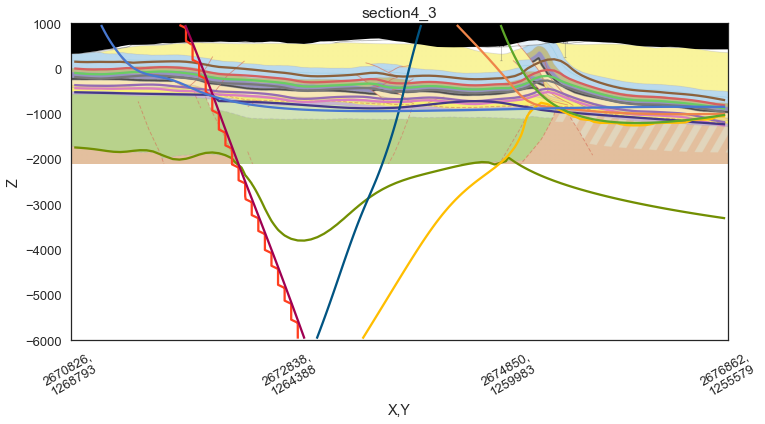

```python
p43 = vv.Plot2D(geo_model)
p43.create_figure((13,6));
sec_name = "section4_3"
a = p43.add_section(sec_name)

# Reading image
img = mpimg.imread('../../figs/Profil4-3_0-14einhalbkm.png')
# Plotting it inplace
a.imshow(img, origin='upper', alpha=.8, extent = (0, 14500, -2100, 1000))

p43.plot_topography(a, sec_name)
p43.plot_contacts(a, sec_name)
```

```python
p43.plot_data(a, sec_name, projection_distance=3000000.)
```

## Plot Profile 4.4

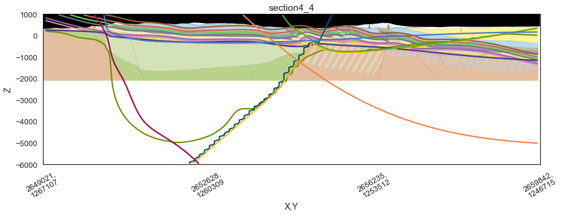

```python
p44 = vv.Plot2D(geo_model)
p44.create_figure((13,6));
sec_name = "section4_4"
a = p44.add_section(sec_name)

# Reading image
img = mpimg.imread('../../figs/Profil4-4_0-23km.png')
# Plotting it inplace
a.imshow(img, origin='upper', alpha=.8, extent = (0, 23000, -2100, 1000))

p43.plot_topography(a, sec_name)
p43.plot_contacts(a, sec_name)
```

```python
p44.plot_data(a, sec_name, projection_distance=21000000.)
```

## Plot Profile 4.8

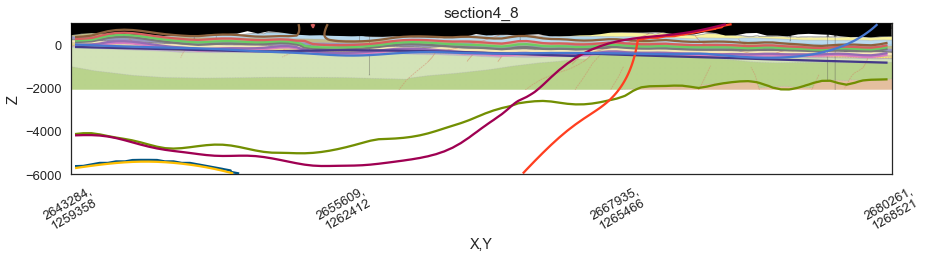

```python
p48 = vv.Plot2D(geo_model)
p48.create_figure((13,6));
sec_name = "section4_8"
a = p48.add_section(sec_name)

# Reading image
img = mpimg.imread('../../figs/Profil4-8_0_38einhalbkm.png')
# Plotting it inplace
a.imshow(img, origin='upper', alpha=.8, extent = (0, 38500, -2100, 1000))

p48.plot_topography(a, sec_name)
p48.plot_contacts(a, sec_name)
```

```python
p48.plot_data(a, sec_name, projection_distance=20500000.)
```

```python
gp.plot_3d(geo_model, show_surfaces=True, show_data=True, show_lith=False,
           image=False, plotter_type='background')
```

```
<gempy.plot.vista.GemPyToVista at 0x1f783e91a08>
```

## Save the Model

```python
geo_model.save_model(path='../../models/20200703_jordan_model_pct_inferred')
```

```
Directory already exists, files will be overwritten
```

```
True
```